# Grapevine xf Analysis 1

Daniel Turek

### Modeling Decisions

##### Plant Random Effects

The plant random effects $(\alpha_{plant\ ID})$ were removed from the model, since there isn’t enough data to support them. Specifically, with only 97 observations from 51 unique plants, there aren’t enough observations from each plant to identify the random effects. Including them, sampling of the random effects trades off with the genotype fixed effects, and the model never converges.

##### Vector bacteria count proportional to source plant bacteria count

The xf concentration in the vectors ($\lambda^i_{vector}$) is modeled as proportional to the xf concentration in the source plant ($\lambda^i_{source\ plant}$):
$$\lambda^i_{vector} = k \cdot \lambda^i_{source\ plant}$$
in terms of unknown model parameter $k>0$. This is a modeling decision which is open for discussion, if you feel a different relationship would be more appropriate. I also tried adding a quadratic term, which was not significant.

##### Source plant and vector observation processes

To model the imperfect detection of xf bacteria in the source plants and vectors, I used a fixed (and separate) probability of detection for each. When measuring the xf concentration in each source plant, there’s a $p_{obs.\ source\ plant}$ probability of a positive detection (e.g., a non-zero measurement).

Similarly, when doing the PCR test to measure the xf concentration in each vector, there’s a $p_{obs.\ vector}$ probability of a positive detection. Each of these probabilities of detection are unknown model parameters.

To implement these detection processes, additional binary latent variables are introduced into the model. The binary-valued $z^i_{source\ plant}$ and $z^i_{vector}$ variables indicate whether a positive detection was made in each source plant or vector.

##### Test plant infection process

Probabiliy of infection for the test plants is modeled (on the logit scale) as a linear function of the vector xf concentration, as:
$$\text{logit}(p^i_{infect}) = \beta_5 + \beta_6 \lambda^i_{vector}$$
This is the same as in your original model. Other covariates can be added, if appropriate.

We see in the results that the vector xf concentration does not have a significant effect on the infection probability of test plants. So the model could be simplified here, to instead have a single parameter to represent probability of infection.

### Hierarchical Model

$$\begin{align}
\text{Priors:} \\
\beta_{1,...,6} &\sim Normal(0, 10000) \\
k &\sim Uniform(0, 100) \\
p_{obs.\ source\ plant},\ p_{obs.\ vector} &\sim Uniform(0, 1) \\
\ \\
\text{Biological model:} \\
\log(\lambda^i_{source\ plant}) &= \beta_1 (genotype^i_{DFS}) + \beta_2 (genotype^i_{WT}) + \beta_3 (distance^i) + \beta_4 (distance^i \cdot genotype^i_{WT}) \\
\lambda^i_{vector} &= k \cdot \lambda^i_{source\ plant} \\
\ \\
\text{Source plant observation model:} \\
z^i_{source\ plant} &\sim Bernoulli(p_{obs.\ source\ plant}) \\
xf^i_{source\ plant} &\sim Poisson(z^i_{source\ plant} \cdot \lambda^i_{source\ plant}) \\
\ \\
\text{Vector observation model:} \\
z^i_{vector} &\sim Bernoulli(p_{obs.\ vector}) \\
xf^i_{vector} &\sim Poisson(z^i_{vector} \cdot \lambda^i_{vector}) \\
\ \\
\text{Test plant infection model:} \\
\text{logit}(p^i_{infect}) &= \beta_5 + \beta_6 \lambda^i_{vector} \\
infected^i &\sim Bernoulli(p^i_{infect}) \\
\end{align}$$

### Data Setup

A few manipulations are done on the input data.

```r
dsf <- readRDS('data/dsf_data_for_nimble.rds')   ## original data file
```

We specify covariates:

- $genotype_{dsf}=1$ when genotype = DSF, and 0 otherwise
- $genotype_{wt}=1$ when genotype = WT, and 0 otherwise
- $genotype_{distance}=distance$ when genotype = WT, and 0 otherwise

With this definition of the $genotype_{distance}$ predictor variable, the corresponding coefficient can be interpreted as change in the coefficient of $distance$, when genotype = WT. See interpretation section for additional explanation.

```r
constants <- list(
    N = dsf$dsfData$N,
    ##nplant = dsf$dsfData$nplant,
    ##plantID = dsf$dsfData$plantID,
    distance = dsf$dsfData$distance,
    ## in original dataset: genotype 1=DSF, 2=WT
    genotype_dsf = ifelse(dsf$dsfData$genotype==1, 1, 0),  ## indicator for DSF
    genotype_wt  = ifelse(dsf$dsfData$genotype==2, 1, 0)   ## indicator for WT
)

## modified genotype_distance: additional distance coefficient for WT
constants$genotype_distance <- constants$genotype_wt * constants$distance
```

The values of the $xf_{vector}$ data are truncated to be integers, for compatibility with the Poisson distribution.

```r
data <- list(
    xf_source_plant = dsf$dsfData$xf_source_plant,
    xf_vector = floor(dsf$dsfData$xf_vector),   ## change to integers
    infected = dsf$dsfData$infected
)
```

We also create three additional vectors of indicies. Thes contain the indicies of the observed (non-NA) data, for each of $xf_{source\ plant}$, $xf_{vector}$, and $infected$. These will be used in the model to skip creating posterior predictive nodes, which speed up the MCMC and overall mixing considerably.

```r
## indices of observed values for each set of data:
constants$obs_ind_plant <- which(!is.na(data$xf_source_plant))
constants$obs_ind_vector <- which(!is.na(data$xf_vector))
constants$obs_ind_infected <- which(!is.na(data$infected))
```

### Model and MCMC

Use [NIMBLE](https://r-nimble.org/) to build the model and corresponding MCMC algorithm.

```r
library(nimble)

code <- nimbleCode({
    ##
    ## linear coefficients
    ## b[1]: genotype=dsf
    ## b[2]: genotype=wt
    ## b[3]: distance
    ## b[4]: genotype=wt and distance interaction
    ## b[5]: logit(prob. of infection) constant term
    ## b[6]: logit(prob. of infection) linear coefficient of vector xf level
    for(i in 1:6) {
        b[i] ~ dnorm(0, sd=10000)
    }
    ##
    ## modeling assumptions:
    ## - measurement of xf in vector has fixed probability of detection
    ## - measurement of xf in plant has fixed probability of detection
    ## - xf level in vector is proportional to xf level in source plant
    ## - logit(prob. of test plant infection) is linear in xf level in vector
    ##
    p_obs_plant ~ dbeta(1, 1)   ## probability of xf detection in source plant
    p_obs_vector ~ dbeta(1, 1)  ## probability of xf detection in vector
    k ~ dunif(0, 100)    ## proportionality between xf in source plant and xf in vector
    ##
    ## Biological model:
    for(i in 1:N) {
        log(lambda_plant[i]) <- b[1]*genotype_dsf[i] + b[2]*genotype_wt[i] + b[3]*distance[i] + b[4]*genotype_distance[i]
        lambda_vector[i] <- k * lambda_plant[i]
    }
    ## only model observed (non-NA) values of xf_source_plant:
    for(iObs in 1:length(obs_ind_plant)) {
        z_plant[obs_ind_plant[iObs]] ~ dbern(p_obs_plant)
        xf_source_plant[obs_ind_plant[iObs]] ~ dpois(z_plant[obs_ind_plant[iObs]] * lambda_plant[obs_ind_plant[iObs]])
    }
    ## only model observed (non-NA) values of xf_vector:
    for(iObs in 1:length(obs_ind_vector)) {
        z_vector[obs_ind_vector[iObs]] ~ dbern(p_obs_vector)
        xf_vector[obs_ind_vector[iObs]] ~ dpois(z_vector[obs_ind_vector[iObs]] * lambda_vector[obs_ind_vector[iObs]])
    }
    ## only model observed (non-NA) values of infected:
    for(iObs in 1:length(obs_ind_infected)) {
        logit(p_infect[obs_ind_infected[iObs]]) <- b[5] + b[6]*lambda_vector[obs_ind_infected[iObs]]
        infected[obs_ind_infected[iObs]] ~ dbern(p_infect[obs_ind_infected[iObs]])
    }
})

inits <- list(
    p_obs_plant = 0.5,
    p_obs_vector = 0.5,
    z_plant = rep(1,constants$N),
    z_vector = rep(1, constants$N),
    b = rep(0,6),
    k = 1
)

Rmodel <- nimbleModel(code, constants, data, inits)

calculate(Rmodel)

conf <- configureMCMC(Rmodel)

## add specialized block samplers:
##conf$addSampler('b[1:2]', 'RW_block')
conf$addSampler('b[5:6]', 'RW_block')

##conf$printSamplers()

##conf$printMonitors()

Rmcmc <- buildMCMC(conf)

system.time(Cmodel <- compileNimble(Rmodel))
```

```
compiling... this may take a minute. Use 'showCompilerOutput = TRUE' to see C++ compiler details.
compilation finished.
   user  system elapsed
   10.088   0.259  10.454
```

```r
system.time(Cmcmc <- compileNimble(Rmcmc, project = Rmodel))
```

```
compiling... this may take a minute. Use 'showCompilerOutput = TRUE' to see C++ compiler details.
compilation finished.
   user  system elapsed
   8.609   0.194   8.886
```

```r
set.seed(0)
system.time(samples <- runMCMC(Cmcmc, 100000, nburnin=10000, nchains=2, returnCodaMCMC=TRUE))
```

```
running chain 1...
|-------------|-------------|-------------|-------------|
|-------------------------------------------------------|
running chain 2...
|-------------|-------------|-------------|-------------|
|-------------------------------------------------------|
   user  system elapsed
   35.731   0.322  36.466
```

### Convergence

We assess convergence of two chains, each with 90,000 post burn-in samples.

The Brooks-Gelman-Rubin diagnostic over two chains of indicates convergence.

```r
library(coda)
```

```r
gelman.diag(samples)
```

```
## Potential scale reduction factors:
##
##              Point est. Upper C.I.
## b[1]                  1          1
## b[2]                  1          1
## b[3]                  1          1
## b[4]                  1          1
## b[5]                  1          1
## b[6]                  1          1
## k                     1          1
## p_obs_plant           1          1
## p_obs_vector          1          1
##
## Multivariate psrf
##
## 1
```

The effective sample size of the first chain is satisfactory, with a minimum of 1,000 effectively independent samples from all posterior dimensions, resulting from the 90,000 post burn-in samples.

```r
round(cbind(
    length = apply(samples[[1]], 2, length),
    ESS    = effectiveSize(samples[[1]])
))
```

```
##              length   ESS
## b[1]          90000 20748
## b[2]          90000 15967
## b[3]          90000  7296
## b[4]          90000  6930
## b[5]          90000  1101
## b[6]          90000  1121
## k             90000 20430
## p_obs_plant   90000 90000
## p_obs_vector  90000 90000
```

The slowest-mixing dimensions, $\beta_5$ and $\beta_6$ exhibited worse mixing, but it was improved though use of a block sampler.

### Posterior Mean, Median, and 95% Credible Intervals

```r
round(cbind(
    `CI Lower` = apply(samples[[1]], 2, function(x) quantile(x, 0.025)),
    `Mean`         = apply(samples[[1]], 2, mean),
    `Median`       = apply(samples[[1]], 2, median),
    `CI Upper` = apply(samples[[1]], 2, function(x) quantile(x, 0.975))
), 5)
```

```
##              CI Lower     Mean   Median CI Upper
## b[1]         17.93629 17.93636 17.93636 17.93643
## b[2]         17.59054 17.59063 17.59063 17.59073
## b[3]         -0.27146 -0.27138 -0.27138 -0.27130
## b[4]          0.08867  0.08878  0.08878  0.08890
## b[5]         -2.37345 -0.67559 -0.67028  1.05514
## b[6]         -0.00016  0.00001  0.00001  0.00017
## k             0.00018  0.00018  0.00018  0.00019
## p_obs_plant   0.37124  0.49968  0.49969  0.62829
## p_obs_vector  0.25713  0.35157  0.35040  0.45248
```

### Interpretations

$\beta_1$, the constant term for genotype dsf, is essentially 17.936.

$\beta_2$, the constant term for genotype wt, is essentially 17.591, slightly lower than the genotype dsf constant term.

$\beta_3$, the coefficient of distance in the log() predictor for vector xf concentration, is essentially -0.271. This value applies to genotype dsf plants.

$\beta_4$, the interaction for genotype wt and distance, is essentially 0.089. This means the coefficient of distance is -0.271 + 0.089 = -0.182 for the genotype wt plants.

$\beta_5$, the contants term in the logit predictor for test plant infection, is within the 95% CI (-2.37, 1.06).

$\beta_6$, the coefficient for vector xf level in the logit predictor for test plant infection is very near to 0, and not significantly different from 0, in the 95% CI (-0.00016, 0.00017).

Unless there are other covariates we might consider here, $\beta_5$ and $\beta_6$ should be removed, and instead use a single probability of test plant infection.

$k$, the proportionality between source plant xf level and vector xf level, is essentally equal to 0.00018.

$p_{obs.\ source plant}$, the probability of xf detection in source plants, is in the 95% CI (0.37, 0.63).

$p_{obs.\ vector}$, the probability of xf detection in vectors, is in the 95% CI (0.26, 0.45).

### Posterior Density Plots

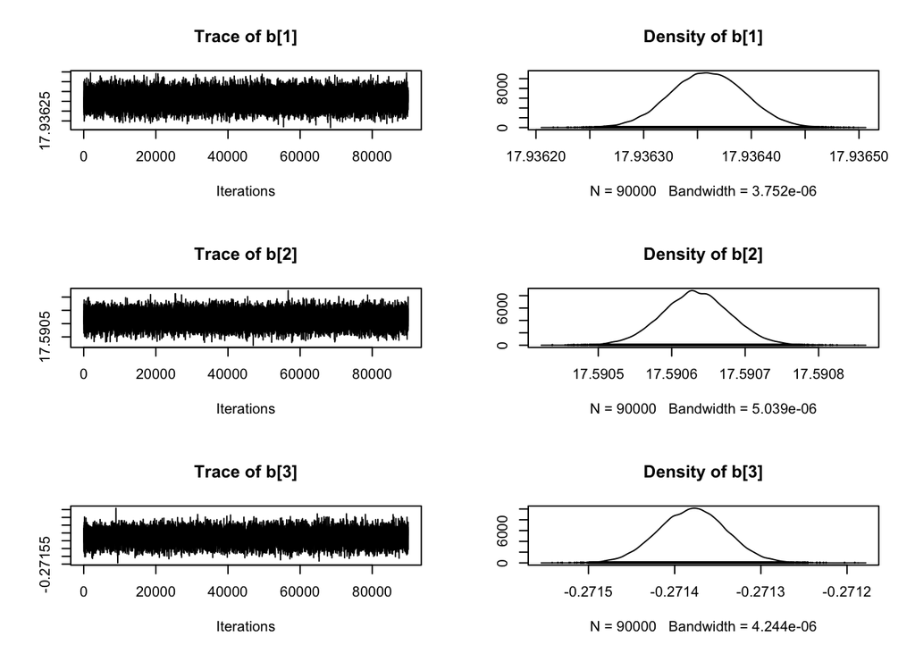

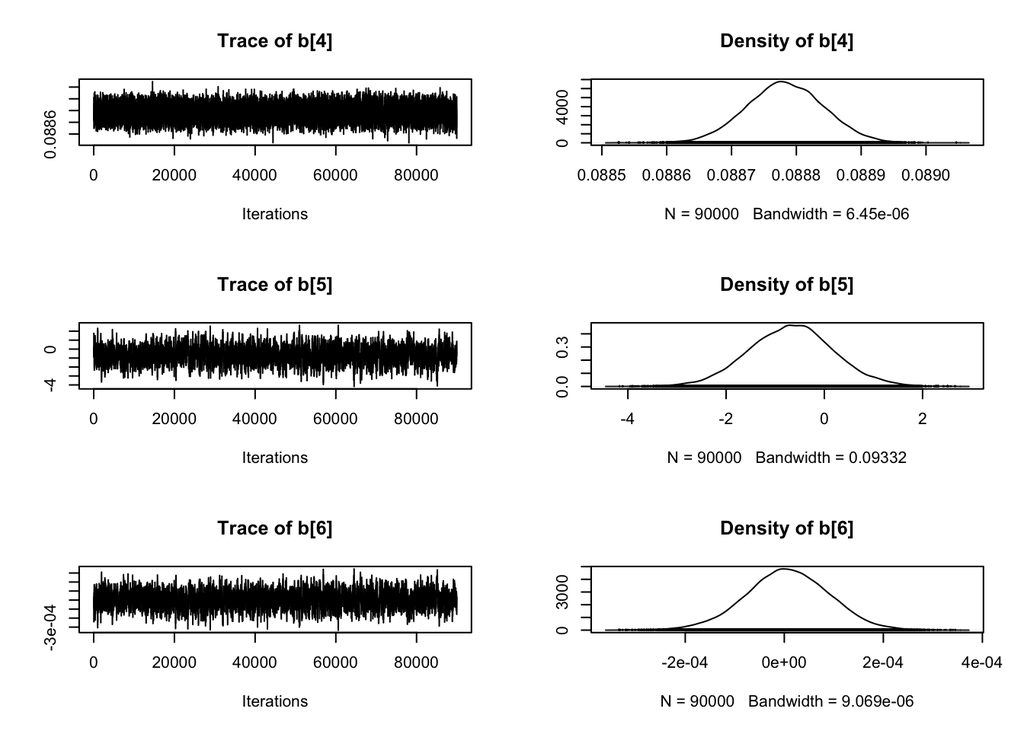

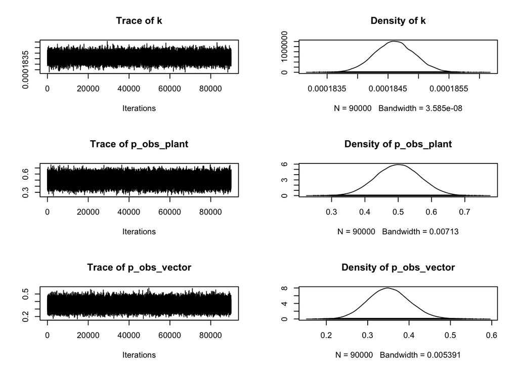

```r
plot(samples[[1]], ask = FALSE)
```